# Linguistic productivity analysis in R: a tutorial

Niek Van Wettere (https://orcid.org/0000-0002-9455-368X)

# 1 Introduction

This tutorial provides an overview of different plotting techniques and statistical methods that can be used to perform a productivity analysis of linguistic constructions. First, it is shown how a dataset comprised of individual attestations (= rows) and variables (= columns) can give rise to different types of plots and analyses. In part 2, a dataset containing productivity measurements (= columns) per construction (= rows) is used as a starting point for further statistical analysis.

# 2 Analysis of dataset [individual attestations X variables]

The first step is to import a csv file with the toy dataset. The data that we are going to use here, contain four variables:

1. ID: an identification number for each example
2. CONSTRUCTION: there are four different constructions, namely cx_1, cx_2, cx_3 and cx_4
3. TYPE: this variable specifies the different types (type_1, type_2 etc.) that occupy a particular slot in the construction
4. CAT: different categories to which the types can belong. These categories could be morphosyntactic, semantic etc.

```r
data<-read.table(file="toy_dataset.csv", header=TRUE, sep=";", comment.char="", fill=TRUE, quote="", row.names=NULL, stringsAsFactors=FALSE, strip.white=TRUE, encoding = "utf-8", blank.lines.skip = TRUE)
head(data)
```

|  | ID | CONSTRUCTION | TYPE | CAT |
| --- | --- | --- | --- | --- |
| 1 | 1 | cx_1 | type_1 | cat_1 |
| 2 | 2 | cx_1 | type_2 | cat_2 |
| 3 | 3 | cx_1 | type_3 | cat_3 |
| 4 | 4 | cx_1 | type_4 | cat_1 |
| 5 | 5 | cx_1 | type_5 | cat_2 |
| 6 | 6 | cx_1 | type_6 | cat_1 |

Note that the first row of the csv file is read as a header and that the strings (e.g. type_1, type_2 etc.) are read as character strings, and not as factors.

## 2.1 Load R packages

In this first step, we will use three packages:

- dplyr: this package facilitates certain data wrangling operations
- ggplot2: this package is very useful to create plots
- zipfR: a package that can assist you in conducting productivity research

```r
.libPaths("C:/R/library") # this line of code tells R where packages are saved on your pc: you might have to adjust this
library('dplyr') ; library("ggplot2") ; library('zipfR')
```

## 2.2 Type-Frequency List (Zipf ranking)

We transform the data such that we obtain the frequency of each type per construction, as exemplified by the dataframe below.

```r
tokens<-select(data, TYPE, CONSTRUCTION) # the relevant variables are selected
type_dataframe<-as.data.frame(table(tokens))
type_dataframe<-filter(type_dataframe, Freq!=0) # zero frequencies are filtered out of the dataframe
cx<-as.character(unique(type_dataframe[,"CONSTRUCTION"]))
(head(type_dataframe))
```

|  | TYPE | CONSTRUCTION | Freq |
| --- | --- | --- | --- |
| 1 | type_1 | cx_1 | 1 |
| 2 | type_10 | cx_1 | 1 |
| 3 | type_100 | cx_1 | 1 |
| 4 | type_101 | cx_1 | 1 |
| 5 | type_102 | cx_1 | 3 |
| 6 | type_103 | cx_1 | 1 |

In the code below, a tfl object is created for each construction, which can be used to visualize a "Type-Frequency List" with the zipfR package.

```r
list_dataframes<-list() # first, we have to set up an empty list
for (i in 1:length(cx)) { # loop
  a<-filter(type_dataframe, CONSTRUCTION == cx[i]) # per construction
  f<-a[,"Freq"]
  type_freq<-tfl(f, k=1:length(f))  # f = vector with frequency of each type & k = integer vector of type IDs
  list_dataframes[[i]]<-type_freq} # each construction and its frequency distribution is a different component of the list
head(list_dataframes[[3]])
```

```
  k   f
3 3 105
4 4  45
5 5   7
1 1   1
2 2   1
6 6   1
```

|  | N | V |
| --- | --- | --- |
|  | 400 | 103 |

The Type-Frequenc List ranks the different types according to decreasing frequency. Note that the symbol "N" stands for the number of tokens in the sample of the construction and "V" indicates the number of different types in the sample of that particular construction. Now that we have all the information, we can plot the Type-Frequency List.

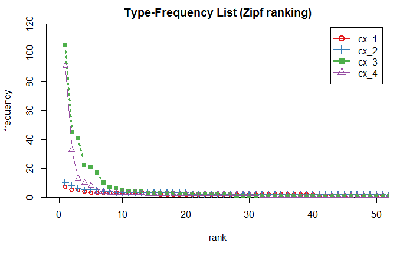

```r
type_freq<-plot(list_dataframes[[1]], list_dataframes[[2]], list_dataframes[[3]], list_dataframes[[4]], bw=TRUE, col=c("#e41a1c", "#377eb8", "#4daf4a", "#984ea3") , legend=cx, xlim=c(0,50), ylim=c(0,120), type="b")
```

Note that you can also use the information in the tfl object to create your own custom-made plot. In the plot below, types of similar frequency are clustered together with the same colour. The horizontal dashed line line corresponds to the mean frequency of the 10 most frequent types.

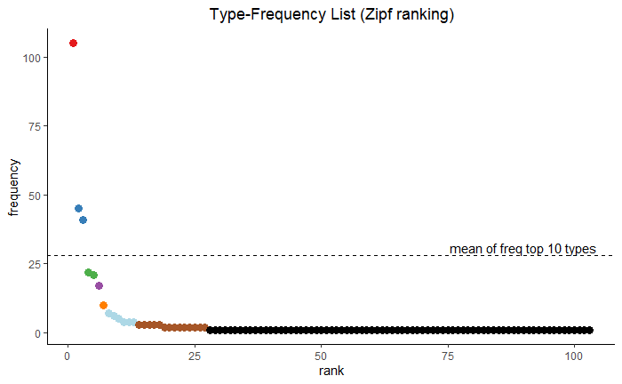

```r
frequency<-sort(list_dataframes[[3]]$f, decreasing = TRUE) # sort frequencies of the types
dist_freq<-dist(frequency, method = "euclidean") # calculate Euclidean distance
clust_dist_freq <- hclust(dist_freq, method = "ward.D2") # hierarchical clustering of the types based on the distances between the frequencies
clusters<-cutree(clust_dist_freq, h=5) # cut the tree at a certain height h to determine a certain number of clusters
type_freq_2<-data.frame(seq(1,103), as.integer(frequency), as.factor(clusters)) # dataframe with information to be plotted
colnames(type_freq_2)<-c("rank", "frequency", "cluster") # change column names of the dataframe
mean_top_10 <- mean(frequency[1:10]) # calculate the mean of the top 10 frequencies
ggplot(data=type_freq_2, aes(x=rank, y=frequency, group=cluster)) + geom_point(aes(color = cluster), size = 3) + scale_color_manual(values=c("#e41a1c", "#377eb8", "#4daf4a", "#984ea3", "#ff7f00", "#add8e6", "#a65628", "#000000")) + theme_classic() + guides(color = FALSE) + ggtitle("Type-Frequency List (Zipf ranking)") + theme(plot.title = element_text(hjust = 0.5)) + geom_hline(yintercept=mean_top_10, linetype = "dashed") + annotate(geom = "text", 90,mean_top_10+3,label = "mean of freq top 10 types") # points are colored according to cluster
```

## 2.3 Frequency spectrum plot

Next, we create a Frequency spectrum plot based on the information of the tfl object.

```r
list_dataframes_spec<-list()
for (i in 1:length(cx)) {
  freq_spec<-tfl2spc(list_dataframes[[i]]) # the function tfl2spc from the ZipfR package
  list_dataframes_spec[[i]]<-freq_spec}
```

The Frequency spectrum plot below shows the frequency for V1 (hapax legomena), V2 (dis legomena) etc., per construction.

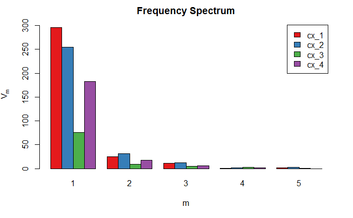

```r
freq_spec<-plot(list_dataframes_spec[[1]], list_dataframes_spec[[2]], list_dataframes_spec[[3]], list_dataframes_spec[[4]], bw=TRUE, barcol=c("#e41a1c", "#377eb8", "#4daf4a", "#984ea3"), legend=cx, m.max=5)
```

## 2.4 Empirical vocabulary growth curve

In this section, we construct an empirical vocabulary growth curve. The first chunk establishes the type frequency for each count of tokens within the window of the sample size.

```r
list_empirical_vgc<-list()
c<-vector()
for (i in 1:length(cx)) {
  a<-filter(tokens, CONSTRUCTION == cx[i]) # per construction

  for (j in 1:length(a[,1])) {  # loop within a loop
    b<-a$TYPE[1:j]
    c<-append(c, length(unique(b))) # the number of types after j tokens (max of j = sample size for that construction) is determined
  }

  d<-c(1:length(a[,1]))
  e<-vgc(N=d, V = c) # vocabulary growth curve function from the ZipfR package

  #N = integer vector of sample sizes N for which vocabulary growth data is available
  #V = vector of corresponding type frequencies

  list_empirical_vgc[[i]]<-e
  c<-vector()
}
```

The next code chunk does the same for the hapax frequency.

```r
list_empirical_vgc_V1<-list()
z<-vector()
for (i in 1:length(cx)) {
  a<-filter(tokens, CONSTRUCTION == cx[i]) # per construction

  for (j in 1:length(a[,1])) {
    b1<-a$TYPE[1:j]
    b2<-as.data.frame(table(b1))
    b3<-filter(b2, Freq==1)  # only types that occur once are taken into account
    b4<-nrow(b3) # the number of hapaxes is counted
    z<-append(z, b4)
  }

  d<-c(1:length(a[,1]))
  e<-vgc(N=d, V = list_empirical_vgc[[i]]$V, Vm=data.frame(z))

  # the information about the type frequencies (V) is extracted from "list_empirical_vgc" established in the chunk above
  # Vm adds the hapax frequencies

  list_empirical_vgc_V1[[i]]<-e
  z<-vector()
}
```

Finally, we draw the empirical vocabulary growth curve for cx_1 and cx_4. The thinner lines correspond to the evolution of the hapax frequency.

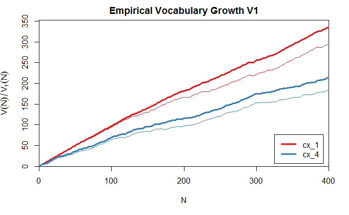

```r
empirical_vgc_with_V1<-plot(list_empirical_vgc_V1[[1]], list_empirical_vgc_V1[[4]], col=c("#e41a1c", "#377eb8"), legend=cx[c(1,4)], xlim=c(0,400), main = "Empirical Vocabulary Growth V1", add.m=1) # "add.m=1" adds the hapax frequencies
```

## 2.5 Hapax type ratio

The hapax type ratio is a different productivity measure, in addition to type frequency and hapax frequency. Similar to how we established the evolution of the type frequency and the hapax frequency throughout the sample, we can now do the same thing for the hapax type ratio, using the ggplot2 package.

```r
hapax_type_ratio_evolution <- list_empirical_vgc_V1[[2]]$V1 / list_empirical_vgc_V1[[2]]$V
hapax_token_evolution <- list_empirical_vgc_V1[[2]]$V1 / list_empirical_vgc_V1[[2]]$N
type_token_evolution <- list_empirical_vgc_V1[[2]]$V / list_empirical_vgc_V1[[2]]$N
N<-rep(c(1:400), 3)   # create a dataframe with three ratio measures
ratio_measures<-rep(c("hapax_type_ratio", "hapax_token_ratio", "type_token_ratio"), each= 400)
ratio_overview<- c(hapax_type_ratio_evolution, hapax_token_evolution, type_token_evolution)
ratio_data_frame<-data.frame(N, ratio_measures, ratio_overview)
head(ratio_data_frame)
```

|  | N | ratio_measures | ratio_overview |
| --- | --- | --- | --- |
| 1 | 1 | hapax_type_ratio | 1 |
| 2 | 2 | hapax_type_ratio | 1 |
| 3 | 3 | hapax_type_ratio | 1 |
| 4 | 4 | hapax_type_ratio | 1 |
| 5 | 5 | hapax_type_ratio | 1 |
| 6 | 6 | hapax_type_ratio | 1 |

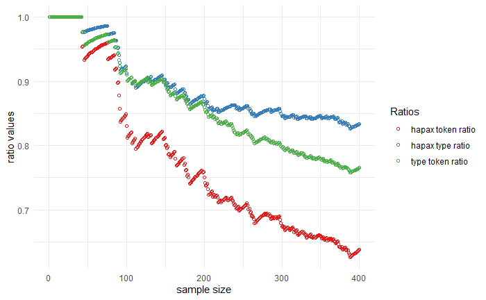

```r
ggplot(data = ratio_data_frame, aes(x=N, y= ratio_overview)) + geom_point(shape=1, aes(colour=ratio_measures)) + theme_minimal() + xlab("sample size") + ylab("ratio values") +  scale_color_manual(name="Ratios", labels=c("hapax token ratio","hapax type ratio","type token ratio"), values=c("#e41a1c", "#377eb8", "#4daf4a"))
```

The plot below displays the same information, but adds a smoother (cf. method = "loess"). The dashed horizontal line indicates the minimum value of the HTR.

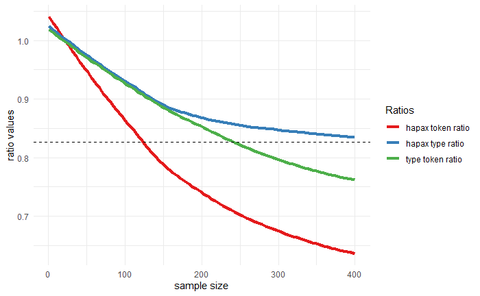

```r
ggplot(data = ratio_data_frame, aes(x=N, y= ratio_overview)) + geom_smooth(size = 1.5, method = "loess", se = FALSE, aes(colour=ratio_measures)) + theme_minimal() + xlab("sample size") + ylab("ratio values") +  scale_color_manual(name="Ratios", labels=c("hapax token ratio","hapax type ratio","type token ratio"), values=c("#e41a1c", "#377eb8", "#4daf4a")) + geom_hline(yintercept=min(hapax_type_ratio_evolution), linetype = "dashed")
```

## 2.6 Summary of all productivity measures

This section demonstrates how to generate a dataframe with different productivity measures per construction.

```r
summary_dataframe<-data.frame()
for (i in 1:length(cx)) {
  summary_dataframe[i,1]<-cx[i]
  summary_dataframe[i,2]<-N(list_dataframes[[i]])  # tokens
  summary_dataframe[i,3]<-V(list_dataframes[[i]]) # types
  summary_dataframe[i,4]<-Vm(list_dataframes[[i]],1)  # hapax
  summary_dataframe[i,5]<-Vm(list_dataframes[[i]],2)  # dis legomena
  summary_dataframe[i,6]<-summary_dataframe[i,3] / summary_dataframe[i,2]  # type_token_ratio
  summary_dataframe[i,7]<-summary_dataframe[i,4] / summary_dataframe[i,2]  # hapax_token_ratio
  summary_dataframe[i,8]<-summary_dataframe[i,4] / summary_dataframe[i,3]  # hapax_type_ratio
  summary_dataframe[i,9]<-summary_dataframe[i,5] / summary_dataframe[i,3]  # dis_type_ratio
  summary_dataframe[i,10]<-attr(list_dataframes[[i]], "f.max") # token_freq of type with highest token_freq
}
colnames(summary_dataframe)<-c("CONSTRUCTION", "token_freq_sample", "type_freq", "hapax_freq", "dis_legomena_freq", "type_token_ratio", "hapax_token_ratio", "hapax_type_ratio", "dis_type_ratio", "highest_token_freq_within_types")
summary_dataframe
```

|  | CONSTRUCTION | token_freq_sample | type_freq | hapax_freq | dis_legomena_freq | type_token_ratio | hapax_token_ratio | hapax_type_ratio | dis_type_ratio | highest_token_freq_within_types |
| --- | --- | --- | --- | --- | --- | --- | --- | --- | --- | --- |
| 1 | cx_1 | 400 | 336 | 296 | 25 | 0.8400 | 0.7400 | 0.8809524 | 0.07440476 | 7 |
| 2 | cx_2 | 400 | 306 | 255 | 31 | 0.7650 | 0.6375 | 0.8333333 | 0.10130719 | 10 |
| 3 | cx_3 | 400 | 103 | 76 | 9 | 0.2575 | 0.1900 | 0.7378641 | 0.08737864 | 105 |
| 4 | cx_4 | 400 | 214 | 183 | 18 | 0.5350 | 0.4575 | 0.8551402 | 0.08411215 | 91 |

## 2.7 Productivity measures within categories

It can be interesting to evaluate productivity measurements per category (morpho-syntactic, semantic etc.). First, we calculate this in the code chunk below.

```r
# token freq per CAT
first_selection<-select(data, CONSTRUCTION, CAT)
dataframe_per_cat<-as.data.frame(table(first_selection))
dataframe_per_cat$CX_CAT <- paste(dataframe_per_cat$CONSTRUCTION, dataframe_per_cat$CAT, sep = "+") # add variable CONSTRUCTION_CAT
dataframe_per_cat <-dataframe_per_cat[,c(-1:-2)]
dataframe_per_cat<-filter(dataframe_per_cat, Freq!=0)
colnames(dataframe_per_cat)<-c("token_freq","CONSTRUCTION_CAT")
# type freq per CAT
second_selection<-select(data, CONSTRUCTION, CAT, TYPE)
dataframe_per_cat_2<-as.data.frame(table(second_selection))
dataframe_per_cat_2$CX_CAT <- paste(dataframe_per_cat_2$CONSTRUCTION, dataframe_per_cat_2$CAT, sep = "+") # add variable CONSTRUCTION_CAT
dataframe_per_cat_2 <-dataframe_per_cat_2[,c(-1:-2)]
dataframe_per_cat_2<-filter(dataframe_per_cat_2, Freq!=0)
type_count<-as.data.frame(table(dataframe_per_cat_2$CX_CAT))
type_count$Var1<-as.character(type_count$Var1)
colnames(type_count)<-c("CONSTRUCTION_CAT", "type_freq")
# hapax freq per CAT
dataframe_per_cat_3<-filter(dataframe_per_cat_2, Freq==1)
hapax_count<-as.data.frame(table(dataframe_per_cat_3$CX_CAT))
colnames(hapax_count)<-c("CONSTRUCTION_CAT", "hapax_freq")
# add a zero hapax count for those combinations CONSTRUCTION-CAT that have no hapaxes, only types with freq > 1
if(length(hapax_count$hapax_freq) != length(type_count$type_freq)) {
  missing_values<-setdiff(type_count$CONSTRUCTION_CAT, hapax_count$CONSTRUCTION_CAT)
  extra <-data.frame(missing_values, rep(0,length(missing_values)))
  colnames(extra)<-c("CONSTRUCTION_CAT","hapax_freq")
  hapax_count <- rbind(hapax_count, extra)}
# merge different dataframes
overview_data<-merge(dataframe_per_cat, type_count, by ="CONSTRUCTION_CAT", all=TRUE)
overview_data<-merge(overview_data, hapax_count, by="CONSTRUCTION_CAT", all=TRUE)
overview_data$CONSTRUCTION<-unlist(lapply(strsplit(overview_data$CONSTRUCTION_CAT, "+", fixed=T), function (x) {x[1]})) # add again the variable CONSTRUCTION on the basis of CONSTRUCTION_CAT
head(overview_data)
```

|  | CONSTRUCTION_CAT | token_freq | type_freq | hapax_freq | CONSTRUCTION |
| --- | --- | --- | --- | --- | --- |
| 1 | cx_1+cat_1 | 214 | 186 | 167 | cx_1 |
| 2 | cx_1+cat_2 | 149 | 126 | 112 | cx_1 |
| 3 | cx_1+cat_3 | 11 | 10 | 9 | cx_1 |
| 4 | cx_1+cat_4 | 18 | 10 | 5 | cx_1 |
| 5 | cx_1+cat_5 | 3 | 2 | 1 | cx_1 |
| 6 | cx_1+cat_6 | 4 | 4 | 4 | cx_1 |

This information can now be visualized in the graph below. The x-axis corresponds to the within-category type frequency, whereas the y-axis corresponds to the within-category hapax frequency. The size of the dots represent the within-category token frequency.

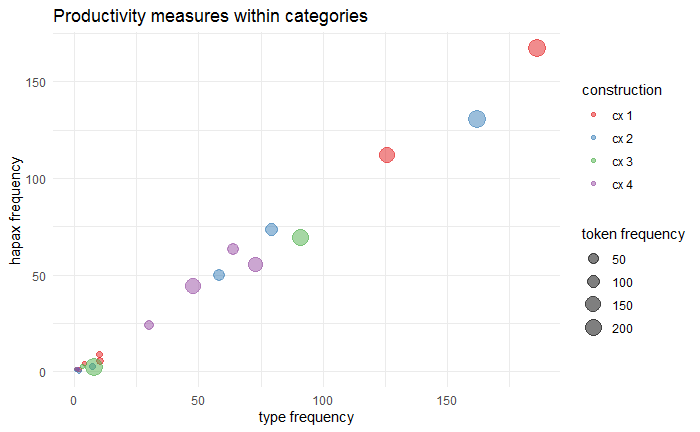

```r
ggplot(data = overview_data, aes(x=type_freq, y= hapax_freq, group = CONSTRUCTION)) + labs(x = "type frequency", y = "hapax frequency", title = "Productivity measures within categories", size = "token frequency") + geom_point(aes(size = token_freq, color = CONSTRUCTION), position = "jitter", alpha = 1/2) + theme_minimal() +  scale_color_manual(name="construction", labels=c("cx 1","cx 2","cx 3", "cx 4"),  values=c("#e41a1c", "#377eb8", "#4daf4a", "#984ea3")) # for geom_point, both "size" and "color" are within the scope of "aes" (aesthetic mappings)
```

## 2.8 LNRE-models

Finally, we can construct a LNRE model to make predictions beyond the attested sample size.

```r
lnre_1<-lnre("fzm", list_dataframes_spec[[3]], exact=TRUE) # fzm = finite Zipf-Mandelbrot
summary(lnre_1)
```

```
finite Zipf-Mandelbrot LNRE model.
Parameters:
   Shape:          alpha = 0.7302146
   Lower cutoff:       A = 1.388456e-19
   Upper cutoff:       B = 0.819483
 [ Normalization:      C = 0.284674 ]
Population size: S = 2.295597e+13
Sampling method: Poisson, with exact calculations.

Parameters estimated from sample of size N = 400:
```

|  | V | V1 | V2 | V3 | V4 | V5 |  |
| --- | --- | --- | --- | --- | --- | --- | --- |
| Observed: | 103.00 | 76.00 | 9.00 | 5.00 | 3.00 | 1.0 | ... |
| Expected: | 103.16 | 75.66 | 10.21 | 4.32 | 2.45 | 1.6 | ... |

```
Goodness-of-fit (multivariate chi-squared test):
```

|  | X2 | df | p |
| --- | --- | --- | --- |
|  | 0.6051574 | 3 | 0.8952507 |

```r
vgc_lnre <- lnre.vgc(lnre_1, (1:1000), variances = TRUE) # lnre.vgc computes expected vocabulary growth curves according to a LNRE model
fzm.spc <- lnre.spc(lnre_1, N(lnre_1)) # lnre.spc computes the expected frequency spectrum of a LNRE model at specified sample size N
```

The aspects coloured in red in the two plots below correspond to what the model predicts.

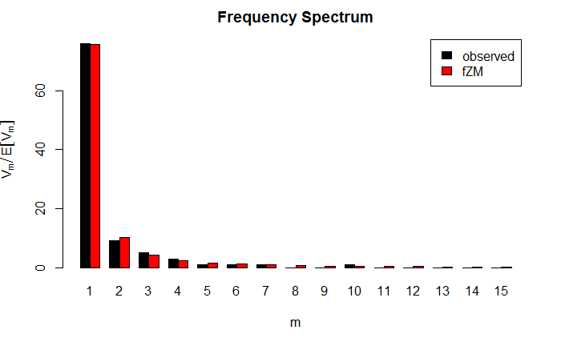

```r
plot(list_dataframes_spec[[3]], fzm.spc, legend=c("observed", "fZM"), main = "Frequency Spectrum")
```

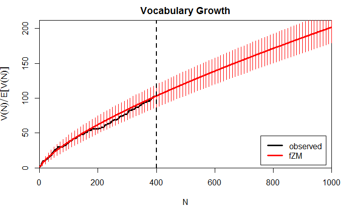

```r
plot(list_empirical_vgc[[3]], vgc_lnre, N0=N(lnre_1), legend=c("observed", "fZM"), xlim= c(0,1000), main = "Vocabulary Growth")
```

As illustrated by the plots below, the predicted vocabulary growth becomes slightly different if we use only the first 300 tokens of the original sample consisting of 400 tokens to base the predictions on.

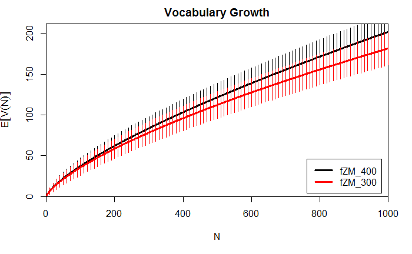

```r
data_2<-select(data, TYPE, CONSTRUCTION)
reduced<-filter(data_2, CONSTRUCTION == "cx_3")
reduced<-reduced[1:300,]
reduced_2<-as.data.frame(table(reduced))
reduced_2<-filter(reduced_2, Freq!=0)
reduced_3<-reduced_2[,"Freq"]
reduced_4<-tfl(reduced_3, k=1:length(reduced_3))
reduced_5<-tfl2spc(reduced_4)
c<-vector()
for (j in 1:length(reduced[,1])) {
    b<-reduced$TYPE[1:j]
    c<-append(c, length(unique(b)))}

d<-c(1:length(reduced[,1]))
reduced_6<-vgc(N=d, V = c)
lnre_2<-lnre("fzm", reduced_5, exact=TRUE)
vgc_lnre_2 <- lnre.vgc(lnre_2, (1:1000), variances = TRUE)
plot(vgc_lnre, vgc_lnre_2, legend=c("fZM_400", "fZM_300"), xlim= c(0,1000), main = "Vocabulary Growth")
```

For this reason, we have to be careful about prediction accuracy far beyond the attested sample size.

# 3 Analysis of dataset with productivity measures

This second part aims to analyze a somewhat larger set of constructions, accompanied by a series of productivity measurements.

```r
(data_bis<-read.table(file="toy_dataset_productivity_measures.csv", header=TRUE, sep=";", comment.char="", fill=TRUE, na.strings = "character", quote="", row.names=NULL, stringsAsFactors=FALSE, strip.white=TRUE, encoding = "utf-8", blank.lines.skip = TRUE))
```

| CONSTRUCTION | TYPE_CX | token_freq_sample | type_freq | hapax_freq | dis_legomena_freq | hapax_type_ratio | dis_type_ratio | token_freq_max | avg_summit_10 | diff_max_avg_10 | diff_r1_r2 | diff_r1_r2_norm |
| --- | --- | --- | --- | --- | --- | --- | --- | --- | --- | --- | --- | --- |
| cx_1 | type_1 | 400 | 250 | 186 | 33 | 0.7440000 | 0.13200000 | 14 | 7.3 | 6.7 | 5 | 10.000000 |
| cx_2 | type_1 | 400 | 311 | 255 | 40 | 0.8199357 | 0.12861736 | 8 | 4.7 | 3.3 | 2 | 5.333333 |
| cx_3 | type_1 | 400 | 336 | 296 | 25 | 0.8809524 | 0.07440476 | 7 | 3.9 | 3.1 | 2 | 8.000000 |
| cx_4 | type_1 | 400 | 326 | 276 | 33 | 0.8466258 | 0.10122699 | 6 | 3.7 | 2.3 | 2 | 16.000000 |
| cx_5 | type_2 | 400 | 81 | 41 | 11 | 0.5061728 | 0.13580247 | 53 | 23.7 | 29.3 | 7 | 1.555556 |
| cx_6 | type_2 | 400 | 97 | 52 | 15 | 0.5360825 | 0.15463918 | 39 | 21.4 | 17.6 | 6 | 2.181818 |
| cx_7 | type_2 | 400 | 183 | 110 | 34 | 0.6010929 | 0.18579235 | 15 | 10.3 | 4.7 | 2 | 2.666667 |
| cx_8 | type_1 | 400 | 306 | 255 | 31 | 0.8333333 | 0.10130719 | 10 | 5.3 | 4.7 | 2 | 3.200000 |
| cx_9 | type_2 | 400 | 103 | 76 | 9 | 0.7378641 | 0.08737864 | 105 | 27.9 | 77.1 | 60 | 12.000000 |
| cx_10 | type_2 | 400 | 60 | 30 | 6 | 0.5000000 | 0.10000000 | 81 | 29.1 | 51.9 | 34 | 6.974359 |

[output cut: 3 more lines]

In addition to more traditional productivity measures, a series of measurements that aim to describe the summit of the frequency distribution are also added. For example:

- avg_summit_10: the average frequency of the first ten ranks
- diff_r1_r2: the frequency difference between the first and the second rank of the distribution

## 3.1 Load R packages

We load some R packages:

```r
.libPaths("C:/R/library")
library('FactoMineR', quietly = TRUE) ; library('factoextra', quietly = TRUE) ; library("corrplot", quietly = TRUE) ; library("PerformanceAnalytics", quietly = TRUE) ; library("MASS", quietly = TRUE) ; library("effects", quietly = TRUE) ; library("vcd", quietly = TRUE) ; library("car", quietly = TRUE) ; library("performance", quietly = TRUE) ; library("DHARMa", quietly = TRUE) ; library("partykit", quietly = TRUE) ; library("rpart", quietly = TRUE) ; library("rpart.plot", quietly = TRUE)
```

## 3.2 Correlations between productivity measurements

Before we tackle the PCA, let's take a look at the correlations between the productivity measurements:

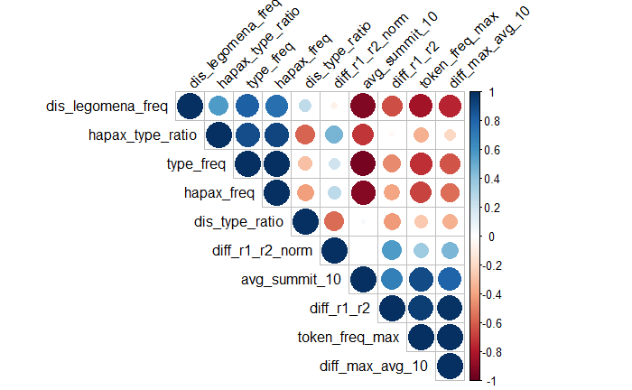

```r
correlations<-round(cor(data_bis[,-1:-3]),2)
corrplot(correlations, type="upper", order="hclust", tl.col="black", tl.srt=45)
```

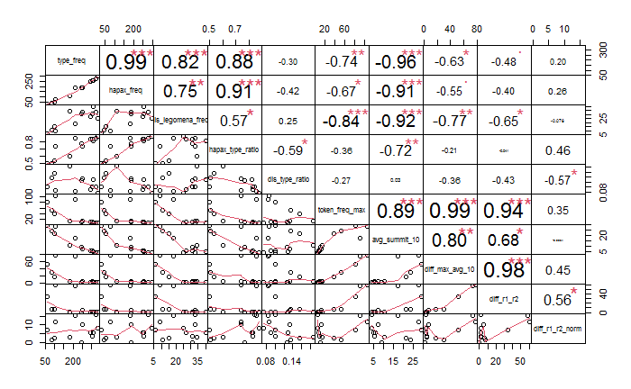

```r
chart.Correlation(data_bis[,-1:-3], histogram=F, pch=19)
```

## 3.3 PCA

Principal Component Analysis (henceforth PCA) is a dimension reduction technique that can be applied by means of the R package FactoMineR. Note that, by default, the variables are standardized (cf. scale.unit = TRUE), prior to the transformation of the variables into principal components.

```r
data_prod<-data_bis
row.names(data_prod)<-data_prod[,1]
data_prod<-data_prod[,c(-1:-3)]
PCA_prod<-PCA(data_prod, graph = FALSE, scale.unit = TRUE)
summary(PCA_prod)
```

```
Call:
PCA(X = data_prod, scale.unit = TRUE, graph = FALSE)


Eigenvalues
                       Dim.1   Dim.2   Dim.3   Dim.4   Dim.5   Dim.6   Dim.7   Dim.8   Dim.9  Dim.10
Variance               6.099   3.002   0.558   0.287   0.027   0.016   0.008   0.003   0.000   0.000
% of var.             60.987  30.015   5.577   2.875   0.274   0.156   0.082   0.034   0.000   0.000
Cumulative % of var.  60.987  91.002  96.579  99.454  99.727  99.883  99.965 100.000 100.000 100.000

Individuals (the 10 first)
                      Dist    Dim.1    ctr   cos2    Dim.2    ctr   cos2    Dim.3    ctr   cos2
cx_1              |  1.672 | -1.319  2.194  0.622 | -0.195  0.097  0.014 |  0.884 10.787  0.280 |
cx_2              |  2.645 | -2.518  7.997  0.907 | -0.147  0.056  0.003 |  0.494  3.362  0.035 |
cx_3              |  2.991 | -2.377  7.126  0.631 |  1.408  5.082  0.222 | -1.082 16.157  0.131 |
cx_4              |  3.192 | -2.447  7.555  0.588 |  1.512  5.856  0.224 |  0.693  6.630  0.047 |
cx_5              |  3.378 |  2.525  8.041  0.559 | -2.137 11.699  0.400 | -0.590  4.803  0.031 |
cx_6              |  3.055 |  1.800  4.087  0.347 | -2.435 15.195  0.635 | -0.045  0.027  0.000 |
cx_7              |  3.057 | -0.528  0.351  0.030 | -2.666 18.220  0.761 |  1.352 25.203  0.196 |
cx_8              |  2.326 | -2.153  5.844  0.857 |  0.178  0.082  0.006 | -0.694  6.643  0.089 |
cx_9              |  4.712 |  4.181 22.050  0.787 |  2.114 11.451  0.201 |  0.178  0.436  0.001 |
cx_10             |  4.231 |  4.126 21.475  0.951 | -0.328  0.276  0.006 | -0.583  4.690  0.019 |

Variables
                     Dim.1    ctr   cos2    Dim.2    ctr   cos2    Dim.3    ctr   cos2
type_freq         | -0.927 14.083  0.859 |  0.371  4.587  0.138 | -0.017  0.051  0.000 |
hapax_freq        | -0.879 12.661  0.772 |  0.466  7.228  0.217 | -0.077  1.072  0.006 |
dis_legomena_freq | -0.916 13.768  0.840 | -0.070  0.165  0.005 |  0.342 21.012  0.117 |
hapax_type_ratio  | -0.657  7.077  0.432 |  0.717 17.150  0.515 | -0.010  0.017  0.000 |
dis_type_ratio    | -0.023  0.009  0.001 | -0.865 24.953  0.749 |  0.487 42.440  0.237 |
token_freq_max    |  0.935 14.326  0.874 |  0.330  3.625  0.109 |  0.056  0.572  0.003 |
avg_summit_10     |  0.989 16.036  0.978 | -0.103  0.354  0.011 | -0.067  0.809  0.005 |
diff_max_avg_10   |  0.868 12.342  0.753 |  0.461  7.067  0.212 |  0.096  1.646  0.009 |
diff_r1_r2        |  0.762  9.531  0.581 |  0.590 11.602  0.348 |  0.165  4.881  0.027 |
diff_r1_r2_norm   |  0.101  0.167  0.010 |  0.836 23.269  0.698 |  0.392 27.500  0.153 |
```

As illustrated by the following scree plot, the first two dimensions capture most of the original variance in the data.

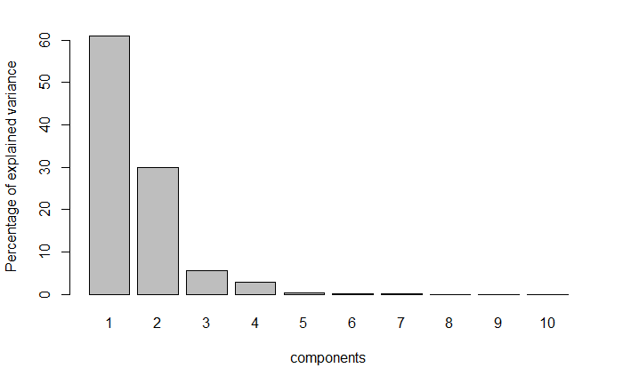

```r
screeplot<-barplot(PCA_prod$eig[,2], names = 1:nrow(PCA_prod$eig), xlab = "components", ylab = "Percentage of explained variance")
```

The fact that the first two dimensions capture more variability is also illustrated by the PCA coordinates of the variables. The coordinates of the first dimensions have a broader IQR than the following dimensions:

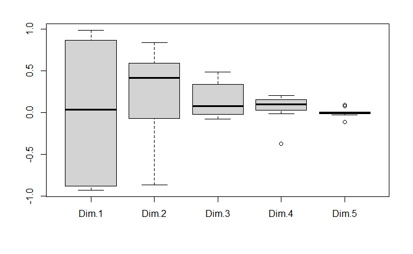

```r
var <- get_pca_var(PCA_prod)
boxplot(var$coord)
```

The PCA enables you to inspect the most important dimensions of variability from two different perspectives, namely the "variables" (i.e. the productivity measures) and the "individuals" (i.e. the constructions). In the graph below, the productivity measures are represented with arrows in the "correlation circle".

- If the arrows point in the same direction, the variables are positively correlated.
- If the arrows point in opposite directions, the variables are negatively correlated.
- If the arrows are orthogonal, the variables are independent.

Variables of which the arrow does not touch the correlation circle are of less representational quality. The coordinates measured at the end of each arrow in the two-dimensional plane correspond to the correlation of that variable with the dimension coinciding with the x-axis and the dimension coinciding with the y-axis, respectively.

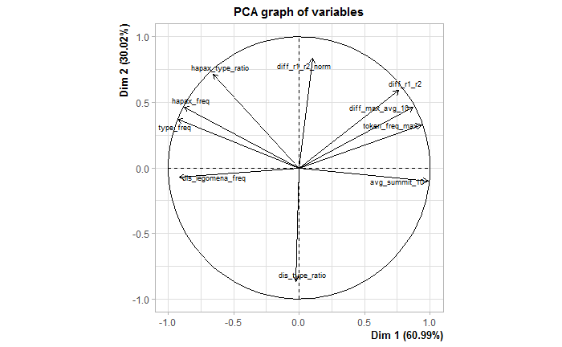

```r
(variables_map<-plot(PCA_prod, choix = "var", cex = 0.6))
```

The dimdesc function is very useful to establish the correlation of each variable with each PCA dimension, accompanied by a p-value.

```r
cat("\n Dimension 1 \n") ; dimdesc(PCA_prod)$Dim.1$quanti
```

```
 Dimension 1
                  correlation      p.value
avg_summit_10       0.9889440 1.809998e-10
token_freq_max      0.9347225 2.841739e-06
diff_max_avg_10     0.8675979 1.216489e-04
diff_r1_r2          0.7624002 2.444631e-03
hapax_type_ratio   -0.6569517 1.470595e-02
hapax_freq         -0.8787080 7.681050e-05
dis_legomena_freq  -0.9163397 1.072986e-05
type_freq          -0.9267635 5.267762e-06
```

```r
cat("\n Dimension 2 \n ") ; dimdesc(PCA_prod)$Dim.2$quanti
```

```
 Dimension 2
                  correlation      p.value
diff_r1_r2_norm    0.8357135 0.0003737159
hapax_type_ratio   0.7174699 0.0057633984
diff_r1_r2         0.5901266 0.0337440216
dis_type_ratio    -0.8654216 0.0001324813
```

Next to the graph of the variables, we can also construct a graph of individuals, in which the constructions are positioned with respect to the two most important PCA dimensions:

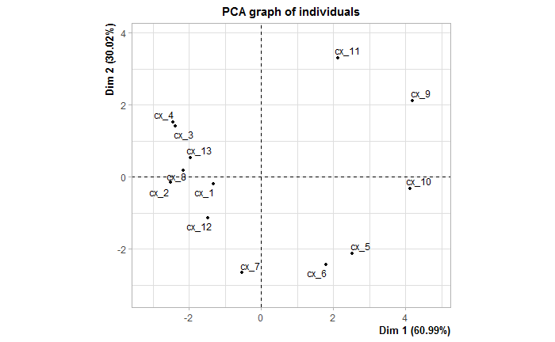

```r
plot(PCA_prod, cex = 0.8, col.ind = "black", choix = c("ind"))
```

The plot can be further enhanced by colouring the constructions according to the variable TYPE_CX. The barycentres of the two types of constructions are also added to the plot and confidence ellipses are drawn around the barycentres.

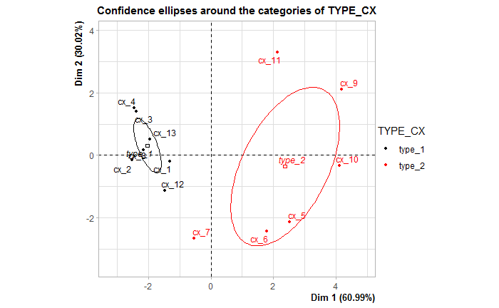

```r
data_prod_2<-data_bis
row.names(data_prod_2)<-data_prod_2[,1]
data_prod_2<-data_prod_2[,c(-1,-3)]
PCA_prod_2<-PCA(data_prod_2, graph = FALSE, scale.unit = TRUE, quali.sup = 1)
plotellipses(PCA_prod_2, cex = 0.8, col.ind = "black", choix = c("ind"), habillage = 1)
```

It is also possible to cluster the individuals within the two-dimensional PCA space:

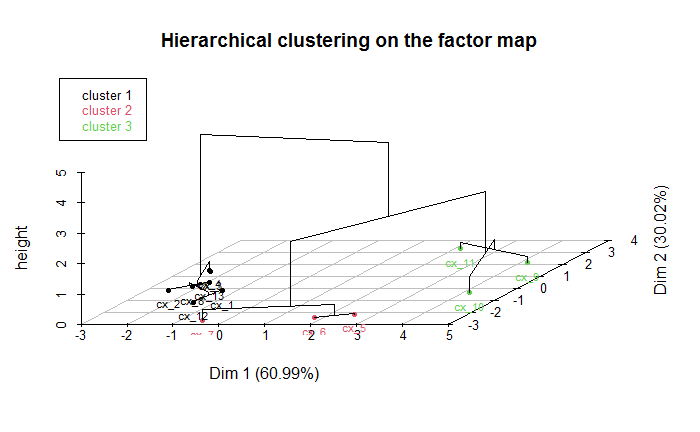

```r
data_prod_3<-data_bis
row.names(data_prod_3)<-data_prod_3[,1]
data_prod_3<-data_prod_3[,c(-1:-3)]
PCA_prod_3<-PCA(data_prod_3, graph = FALSE, scale.unit = T, ncp = 2)
res.hcpc <- HCPC(PCA_prod_3, nb.clust = -1, graph = FALSE, method = "ward", metric = "euclidean") # min = 2, max = 10
plot(res.hcpc)
```

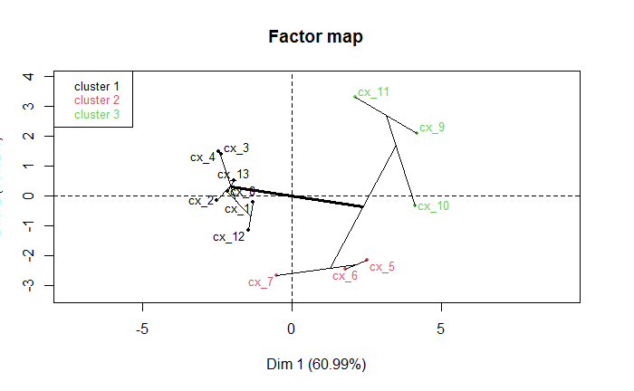

```r
plot(res.hcpc, choice ="map")
```

Finally, we can try to combine the "variable view" and the "individual view" into one unified biplot:

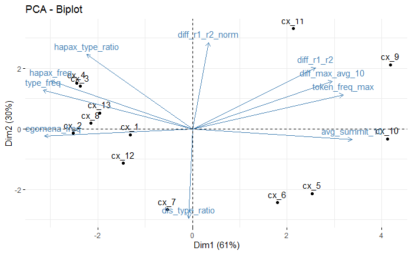

```r
fviz_pca_biplot(PCA_prod)
```

## 3.4 Regression tree

Another potentially interesting way to gain insight into the data is to construct a tree regression model. The following tree demonstrates that the difference between the first and second rank (cf. diff_r1_r2) only makes a difference in predicting the hapax frequency for constructions with a large value for avg_summit_10.

```r
tree_model_1<-rpart(hapax_freq ~ avg_summit_10 + diff_r1_r2, data = data_bis, method = "poisson", control = rpart.control(minsplit = 4))
printcp(tree_model_1)
```

```
Rates regression tree:
rpart(formula = hapax_freq ~ avg_summit_10 + diff_r1_r2, data = data_bis,
    method = "poisson", control = rpart.control(minsplit = 4))

Variables actually used in tree construction:
[1] avg_summit_10 diff_r1_r2

Root node error: 761.82/13 = 58.602

n= 13

        CP nsplit rel error  xerror    xstd
1 0.792650      0  1.000000 1.19896 0.29301
2 0.132581      1  0.207350 0.71054 0.28216
3 0.022071      2  0.074769 0.54311 0.27728
4 0.013246      3  0.052698 0.40769 0.17530
5 0.010000      4  0.039452 0.37189 0.15473
```

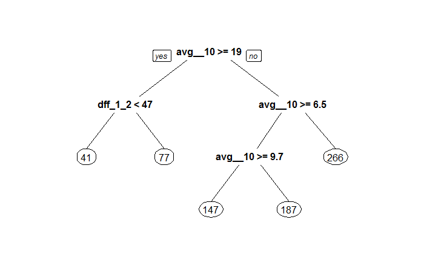

```r
prp(tree_model_1, varlen = 7)
```

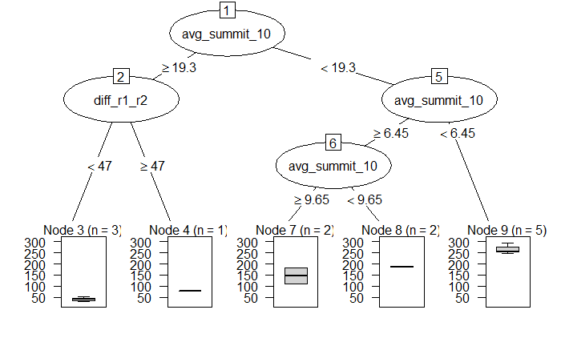

```r
plot(as.party(tree_model_1))
```

Contrary to the previous tree, this new model only recognizes the variable avg_summit_10 to split the data.

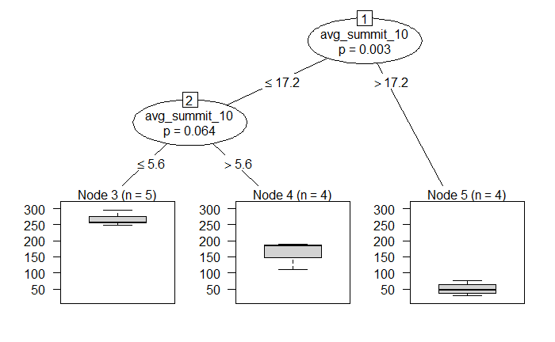

```r
tree_model_2<-glmtree(hapax_freq ~ avg_summit_10 * diff_r1_r2, data = data_bis, epsilon =1, alpha = 0.2, minsize = 1, family = "poisson")
plot(tree_model_2)
```

## 3.5 Regression for count data: negative binomial

In this last part, we attempt to establish a negative binomial regression model, suited for count data. As outcome variable, the productivity measurement hapax frequency is chosen. The explanatory variables are avg_summit_10 and diff_r1_r2. Of course, this model is only based on a limited number of constructions: ideally, we would have more data points to base the estimation on.

```r
mean(data_bis$hapax_freq)
```

```
[1] 169.0769
```

```r
var(data_bis$hapax_freq)
```

```
[1] 9264.91
```

Clearly, the variance of the variable "hapax frequency" far exceeds the mean, which makes a poisson model less appropriate.

### 3.5.1 Model summary

Let's now construct the model. Since the sample sizes are equal, we do not include an "offset" term.

```r
nbGLM <- glm.nb(hapax_freq ~ avg_summit_10 + diff_r1_r2, data=data_bis)
summary(nbGLM)
```

```
Call:
glm.nb(formula = hapax_freq ~ avg_summit_10 + diff_r1_r2, data = data_bis,
    init.theta = 218.4165792, link = log)

Deviance Residuals:
    Min       1Q   Median       3Q      Max
-2.3703  -0.4386   0.2280   0.6017   1.6944

Coefficients:
               Estimate Std. Error z value Pr(>|z|)
(Intercept)    6.005223   0.051408  116.81  < 2e-16 ***
avg_summit_10 -0.103583   0.005803  -17.85  < 2e-16 ***
diff_r1_r2     0.017756   0.002203    8.06  7.6e-16 ***
---
Signif. codes:  0 ‘***’ 0.001 ‘**’ 0.01 ‘*’ 0.05 ‘.’ 0.1 ‘ ’ 1

(Dispersion parameter for Negative Binomial(218.4166) family taken to be 1)

    Null deviance: 465.070  on 12  degrees of freedom
Residual deviance:  13.619  on 10  degrees of freedom
AIC: 116.27

Number of Fisher Scoring iterations: 1

              Theta:  218
          Std. Err.:  226

 2 x log-likelihood:  -108.273
```

Comparison with models:

```r
nbGLM.null <- glm.nb(hapax_freq ~ 1, data=data_bis)
nbGLM.2 <- glm.nb(hapax_freq ~ avg_summit_10, data=data_bis)
nbGLM.4 <- glm.nb(hapax_freq ~ avg_summit_10 * diff_r1_r2, data=data_bis)
anova(nbGLM.null, nbGLM.2, nbGLM, nbGLM.4, test="Chisq")
```

```
Likelihood ratio tests of Negative Binomial Models

Response: hapax_freq
                       Model      theta Resid. df    2 x log-lik.   Test    df  LR stat.      Pr(Chi)
1                          1   2.360924        12       -155.2185
2              avg_summit_10  12.467794        11       -133.8432 1 vs 2     1 21.375309 3.776029e-06
3 avg_summit_10 + diff_r1_r2 218.416579        10       -108.2730 2 vs 3     1 25.570218 4.265728e-07
4 avg_summit_10 * diff_r1_r2 312.734505         9       -106.9983 3 vs 4     1  1.274685 2.588895e-01
```

`  
The rootogram below indicates to what extent the expected counts correspond to the observed counts:

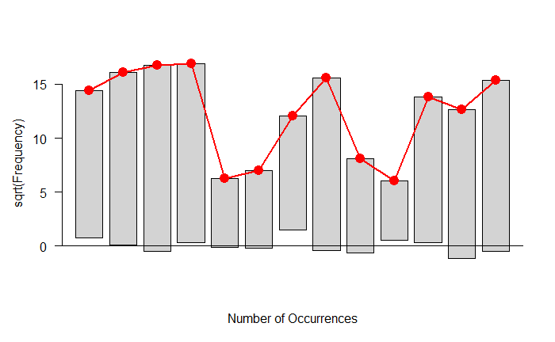

```r
fitted_hapax_freq<-fitted(nbGLM)
observed_hapax_freq<-data_bis$hapax_freq
rootogram(observed_hapax_freq, fitted_hapax_freq)
```

### 3.5.2 Effect plots

In order to interpret the model, we draw an effect plot. The first plot seems to give us unrealistic predictions for the lower values of avg_summit_10:

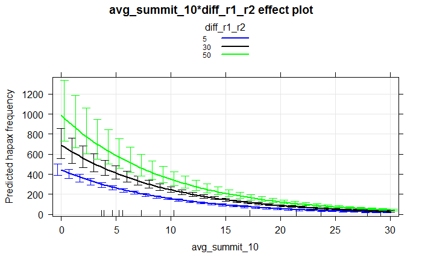

```r
plot(Effect(focal.predictors = c("avg_summit_10", "diff_r1_r2"), mod = nbGLM, x.var = "avg_summit_10", xlevels=list(avg_summit_10=c(0:30), diff_r1_r2=c(5,30,50))),  type="response", lines=list(multiline=TRUE, col=c("blue", "black", "green")), confint=list(style="bars"),  ylab="Predicted hapax frequency", grid=TRUE)
```

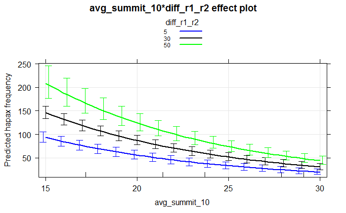

```r
plot(Effect(focal.predictors = c("avg_summit_10", "diff_r1_r2"), mod = nbGLM, x.var = "avg_summit_10", xlevels=list(avg_summit_10=c(15:30), diff_r1_r2=c(5,30,50))),  type="response", lines=list(multiline=TRUE, col=c("blue", "black", "green")), confint=list(style="bars"),  ylab="Predicted hapax frequency", grid=TRUE)
```

The plot above can also be visualized as follows (but the message remains the same):

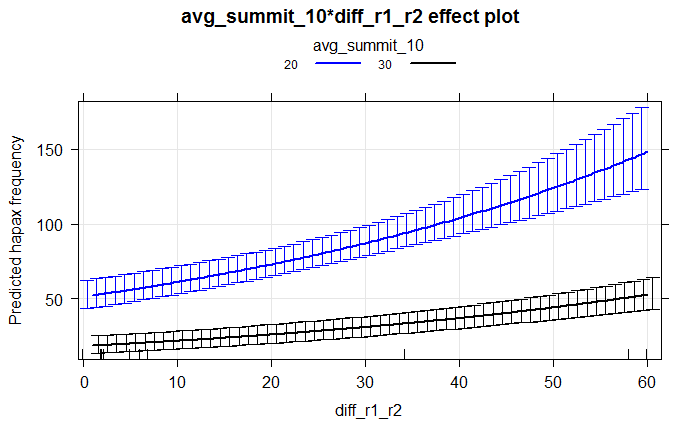

```r
plot(Effect(focal.predictors = c("avg_summit_10", "diff_r1_r2"), mod = nbGLM, x.var = "diff_r1_r2", xlevels=list(avg_summit_10=c(20,30), diff_r1_r2=c(1:60))),  type="response", lines=list(multiline=TRUE, col=c("blue", "black")), confint=list(style="bars"),  ylab="Predicted hapax frequency", grid=TRUE)
```

### 3.5.3 Model diagnostics

In this last section, we evaluate the model by means of some model diagnostics. First, we inspect the residuals:

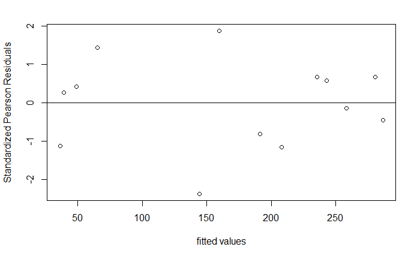

```r
plot(rstandard(nbGLM, type="pearson") ~ fitted(nbGLM), xlab = "fitted values", ylab="Standardized Pearson Residuals")
abline(h=0)
```

```
    DHARMa nonparametric dispersion test via sd of residuals fitted vs. simulated

data:  simulationOutput
ratioObsSim = 0.97167, p-value = 0.928
alternative hypothesis: two.sided
```

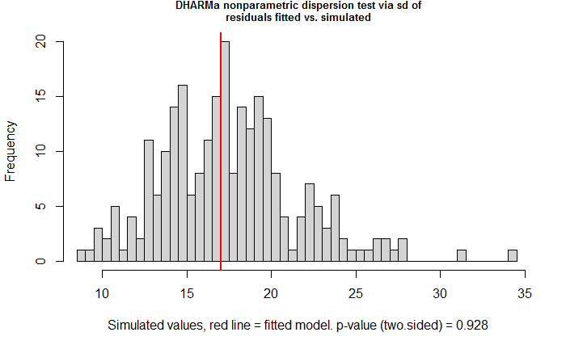

```r
testDispersion(nbGLM)
```

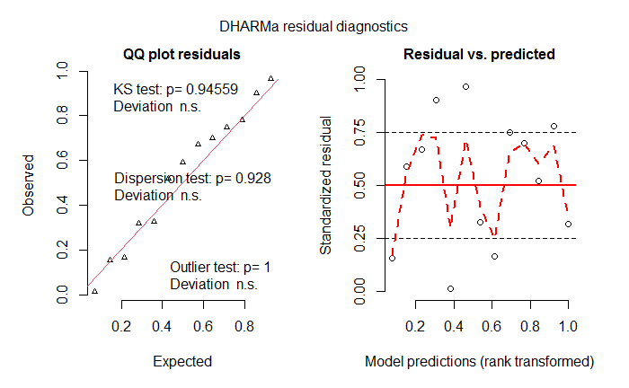

```r
simulationOutput<-simulateResiduals(fittedModel = nbGLM, plot = F)
plot(simulationOutput, quantreg = F)
```

We also check for influential data points:

|  | StudRes | Hat | CookD |
| --- | --- | --- | --- |
| 7 | -2.800245 | 0.1205076 | 0.2584286 |
| 9 | 1.238463 | 0.3620867 | 0.3917851 |
| 11 | -0.675647 | 0.7115120 | 0.5367516 |
| 12 | 1.697126 | 0.1234734 | 0.1670058 |

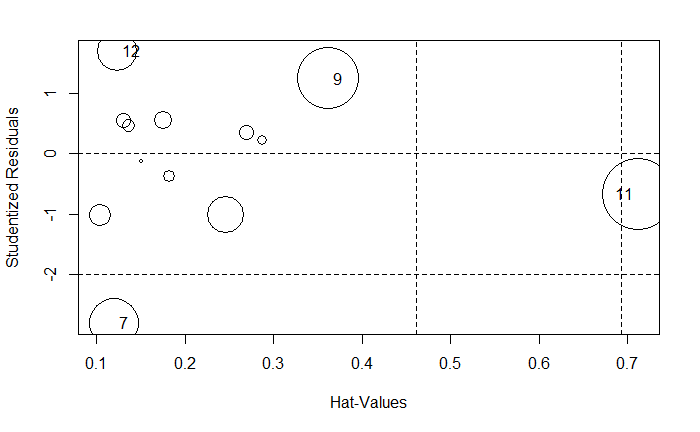

```r
influencePlot(nbGLM)
```

The following code checks for multi-collinearity, heteroscedasticity and autocorrelation:

```r
check_collinearity(nbGLM)
```

```
# Check for Multicollinearity

Low Correlation

     Parameter  VIF Increased SE
 avg_summit_10 2.11         1.45
    diff_r1_r2 2.11         1.45
```

```r
check_heteroscedasticity(nbGLM)
```

```
OK: Error variance appears to be homoscedastic (p = 0.565).
```

```r
check_autocorrelation(nbGLM)
```

[output not shown]

# 4 References

```r
print(citation('dplyr'), bibtex = FALSE)
```

```
  Hadley Wickham, Romain François, Lionel Henry and Kirill Müller (2020). dplyr: A Grammar of Data Manipulation. R package version 1.0.0.
  https://CRAN.R-project.org/package=dplyr
```

```r
print(citation('zipfR'), bibtex = FALSE)
```

```
  Evert, Stefan and Baroni, Marco (2007). "zipfR: Word frequency distributions in R." In Proceedings of the 45th Annual Meeting of the
  Association for Computational Linguistics, Posters and Demonstrations Sessions, pages 29-32, Prague, Czech Republic. (R package version
  0.6-66 of 2019-09-30)

Thanks for crediting our work! We hope that you enjoy using the package and would like to hear your comments, criticism and suggestions for
future enhancements.
```

```r
print(citation("ggplot2"), bibtex = FALSE)
```

```
  H. Wickham. ggplot2: Elegant Graphics for Data Analysis. Springer-Verlag New York, 2016.
```

```r
print(citation('FactoMineR'), bibtex = FALSE)
```

```
  Sebastien Le, Julie Josse, Francois Husson (2008). FactoMineR: An R Package for Multivariate Analysis. Journal of Statistical Software,
  25(1), 1-18. 10.18637/jss.v025.i01
```

```r
print(citation('factoextra'), bibtex = FALSE)
```

```
  Alboukadel Kassambara and Fabian Mundt (2020). factoextra: Extract and Visualize the Results of Multivariate Data Analyses. R package
  version 1.0.7. https://CRAN.R-project.org/package=factoextra
```

```r
print(citation("corrplot"), bibtex = FALSE)
```

```
  Taiyun Wei and Viliam Simko (2017). R package "corrplot": Visualization of a Correlation Matrix (Version 0.84). Available from
  https://github.com/taiyun/corrplot
```

```r
print(citation("PerformanceAnalytics"), bibtex = FALSE)
```

```
  Brian G. Peterson and Peter Carl (2020). PerformanceAnalytics: Econometric Tools for Performance and Risk Analysis. R package version
  2.0.4. https://CRAN.R-project.org/package=PerformanceAnalytics
```

```r
print(citation("MASS"), bibtex = FALSE)
```

```
  Venables, W. N. & Ripley, B. D. (2002) Modern Applied Statistics with S. Fourth Edition. Springer, New York. ISBN 0-387-95457-0
```

```r
print(citation("effects"), bibtex = FALSE)
```

```
  John Fox and Sanford Weisberg (2019). An R Companion to Applied Regression, 3rd Edition. Thousand Oaks, CA <http://tinyurl.com/carbook>

For predictor effects or partial residuals also cite:

  John Fox, Sanford Weisberg (2018). Visualizing Fit and Lack of Fit in Complex Regression Models with Predictor Effect Plots and Partial
  Residuals. Journal of Statistical Software, 87(9), 1-27. URL https://www.jstatsoft.org/v087/i09.

For generalized linear models also cite:

  John Fox (2003). Effect Displays in R for Generalised Linear Models. Journal of Statistical Software, 8(15), 1-27. URL
  http://www.jstatsoft.org/v08/i15/.

For usage in multinomial and proportional-odds logit models also cite:

  John Fox, Jangman Hong (2009). Effect Displays in R for Multinomial and Proportional-Odds Logit Models: Extensions to the effects Package.
  Journal of Statistical Software, 32(1), 1-24. URL http://www.jstatsoft.org/v32/i01/.
```

```r
print(citation("vcd"), bibtex = FALSE)
```

[output not shown]

```r
print(citation("car"), bibtex = FALSE)
```

```
  John Fox and Sanford Weisberg (2019). An {R} Companion to Applied Regression, Third Edition. Thousand Oaks CA: Sage. URL:
  https://socialsciences.mcmaster.ca/jfox/Books/Companion/
```

```r
print(citation("performance"), bibtex = FALSE)
```

```
  Daniel Lüdecke, Dominique Makowski, Philip Waggoner and Indrajeet Patil (2020). performance: Assessment of Regression Models Performance. R
  package version 0.4.7. https://CRAN.R-project.org/package=performance
```

```r
print(citation("DHARMa"), bibtex = FALSE)
```

```
  Florian Hartig (2020). DHARMa: Residual Diagnostics for Hierarchical (Multi-Level / Mixed) Regression Models. R package version 0.3.2.0.
  https://CRAN.R-project.org/package=DHARMa
```

```r
print(citation("partykit"), bibtex = FALSE)
```

```
  Torsten Hothorn, Achim Zeileis (2015). partykit: A Modular Toolkit for Recursive Partytioning in R. Journal of Machine Learning Research,
  16, 3905-3909. URL http://jmlr.org/papers/v16/hothorn15a.html

If ctree() is used additionally cite:

  Torsten Hothorn, Kurt Hornik and Achim Zeileis (2006). Unbiased Recursive Partitioning: A Conditional Inference Framework. Journal of
  Computational and Graphical Statistics, 15(3), 651--674, DOI: 10.1198/106186006X133933

If mob() is used additionally cite:

  Achim Zeileis, Torsten Hothorn and Kurt Hornik (2008). Model-Based Recursive Partitioning. Journal of Computational and Graphical
  Statistics, 17(2), 492--514, DOI: 10.1198/106186008X319331
```

```r
print(citation("rpart"), bibtex = FALSE)
```

```
  Terry Therneau and Beth Atkinson (2019). rpart: Recursive Partitioning and Regression Trees. R package version 4.1-15.
  https://CRAN.R-project.org/package=rpart
```

```r
print(citation("rpart.plot"), bibtex = FALSE)
```

```
  Stephen Milborrow (2019). rpart.plot: Plot 'rpart' Models: An Enhanced Version of 'plot.rpart'. R package version 3.0.8.
  https://CRAN.R-project.org/package=rpart.plot

ATTENTION: This citation information has been auto-generated from the package DESCRIPTION file and may need manual editing, see
‘help("citation")’.
```